# Tugas Evaluasi

02-11-2018

Nama: **Maestro Trastanechora**

Tipedata Dataframes pada Pandas  
Pembimbing: Muhammad Hilman Fatoni

**Note untuk pembimbing: *Maaf pak, mungkin bakal banyak catatan yang kurang perlu, namun sayang untuk dihapus karena ini sekalian sebagai catatan pembelajaran saya*.**

**Navigasi:** *Silahkan klik butir list soal di bawah ini untuk langsung melihat poin tersebut dan klik judul jawaban untuk kembali ke list soal.*.

**Important Note:** *Bagi teman-teman yang mau belajar tutorial tugas ini mohon download versi HTML atau IPYNB di link berikut supaya bisa sebagai sarana ber-experiment dan untuk tampilan yang tentunya lebih baik dari pdf:*.

Download catatan .ipynb atau HTML via [**Google Drive**](https://drive.google.com/drive/folders/1Bo-FOqeZhzbVNjeVI97hXpR8RkhkwYEP?usp=sharing) atau [**GitHub**](https://github.com/trastanechora/digitalent2018)

Atau bisa buka dan share online dengan [link ini :)](https://nbviewer.jupyter.org/github/trastanechora/digitalent2018/blob/master/Tugas/Tugas%2001/Mae%20-%20Tugas%20Tipedata%20Dataframes%20pada%20Pandas%20-%2002.11.2018.ipynb)

# Soal:

1. Kerjakan semua latihan pada [slide ini](https://drive.google.com/drive/u/0/folders/13sWPHYusfLffZAEptte-5LqbR9PE5fTA)!!
   1. Latihan #1
      1. Cobalah untuk membaca 10, 20, 50 baris pertama;
      2. Dapatkah Anda menebak cara melihat beberapa baris terakhir;
   2. Latihan #2
      1. Temukan berapa banyak catatan yang dimiliki dataframe ini;
      2. Berapa banyak elemen di sana?
      3. Apa nama kolomnya?
      4. Apa jenis kolom yang kita miliki dalam bingkai data ini?
   3. Latihan #3
      1. Berikan ringkasan untuk kolom numerik dalam kumpulan data;
      2. Hitung standar deviasi untuk semua kolom numerik;
      3. Berapakah nilai rata-rata dari 50 rekaman pertama dalam dataset?
   4. Latihan #4
      1. Hitung statistik dasar (mean, median, modus) untuk kolom gaji;
      2. Temukan berapa banyak nilai di kolom gaji (gunakan metode count);
      3. Hitung gaji rata-rata;
2. Mengambil iris dataset dari sklearn.datasets (menggunakan import)
3. Membuat iris dataframe dari iris dataset
4. Memplot 5 baris pertama dari iris dataframe
5. Mencari statistika dasar dari iris dataframe

**Note:** *Bagi teman-teman yang ingin mengunduh file jupyter note (.ipynb) saya bisa klik link di atas :)*.

```python
import pandas as pd
import numpy as np
```

Untuk memulai, langkah awal yang harus dilakukan adalah import Pandas dan Numpy dengan menginisiasi script di atas.

# Tugas #1 -- Latihan 1

Soal:

1. Cobalah untuk membaca 10, 20, 50 baris pertama;
2. Dapatkah Anda menebak cara melihat beberapa baris terakhir;

Import file .csv yang berisi dataframe dengan menggunakan Pandas read_csv dari link: http://rcs.bu.edu/examples/python/data_analysis/Salaries.csv dan kemudian menyimpannya ke variabel yang diberi nama "df"

```python
df = pd.read_csv("http://rcs.bu.edu/examples/python/data_analysis/Salaries.csv")
```

Untuk melihat hasilnya bisa langsung diketikkan nama variabel tersebut:

Note: Jika anggota dari dataset tersebut jumlahnya sangat banyak maka tidak semuanya akan ditampilkan, perhatikan index nomor 30-47!

```python
df
```

|  | rank | discipline | phd | service | sex | salary |
| --- | --- | --- | --- | --- | --- | --- |
| 0 | Prof | B | 56 | 49 | Male | 186960 |
| 1 | Prof | A | 12 | 6 | Male | 93000 |
| 2 | Prof | A | 23 | 20 | Male | 110515 |
| 3 | Prof | A | 40 | 31 | Male | 131205 |
| 4 | Prof | B | 20 | 18 | Male | 104800 |
| 5 | Prof | A | 20 | 20 | Male | 122400 |
| 6 | AssocProf | A | 20 | 17 | Male | 81285 |
| 7 | Prof | A | 18 | 18 | Male | 126300 |
| 8 | Prof | A | 29 | 19 | Male | 94350 |
| 9 | Prof | A | 51 | 51 | Male | 57800 |
| 10 | Prof | B | 39 | 33 | Male | 128250 |
| 11 | Prof | B | 23 | 23 | Male | 134778 |
| 12 | AsstProf | B | 1 | 0 | Male | 88000 |
| 13 | Prof | B | 35 | 33 | Male | 162200 |
| 14 | Prof | B | 25 | 19 | Male | 153750 |
| 15 | Prof | B | 17 | 3 | Male | 150480 |
| 16 | AsstProf | B | 8 | 3 | Male | 75044 |
| 17 | AsstProf | B | 4 | 0 | Male | 92000 |
| 18 | Prof | A | 19 | 7 | Male | 107300 |
| 19 | Prof | A | 29 | 27 | Male | 150500 |
| 20 | AsstProf | B | 4 | 4 | Male | 92000 |
| 21 | Prof | A | 33 | 30 | Male | 103106 |
| 22 | AsstProf | A | 4 | 2 | Male | 73000 |
| 23 | AsstProf | A | 2 | 0 | Male | 85000 |
| 24 | Prof | A | 30 | 23 | Male | 91100 |
| 25 | Prof | B | 35 | 31 | Male | 99418 |
| 26 | Prof | A | 38 | 19 | Male | 148750 |
| 27 | Prof | A | 45 | 43 | Male | 155865 |
| 28 | AsstProf | B | 7 | 2 | Male | 91300 |
| 29 | Prof | B | 21 | 20 | Male | 123683 |
| ... | ... | ... | ... | ... | ... | ... |
| 48 | Prof | B | 17 | 17 | Female | 111512 |
| 49 | Prof | B | 17 | 18 | Female | 122960 |
| 50 | AsstProf | B | 10 | 5 | Female | 97032 |
| 51 | Prof | B | 20 | 14 | Female | 127512 |
| 52 | Prof | A | 12 | 0 | Female | 105000 |
| 53 | AsstProf | A | 5 | 3 | Female | 73500 |
| 54 | AssocProf | A | 25 | 22 | Female | 62884 |
| 55 | AsstProf | A | 2 | 0 | Female | 72500 |
| 56 | AssocProf | A | 10 | 8 | Female | 77500 |
| 57 | AsstProf | A | 3 | 1 | Female | 72500 |
| 58 | Prof | B | 36 | 26 | Female | 144651 |
| 59 | AssocProf | B | 12 | 10 | Female | 103994 |
| 60 | AsstProf | B | 3 | 3 | Female | 92000 |
| 61 | AssocProf | B | 13 | 10 | Female | 103750 |
| 62 | AssocProf | B | 14 | 7 | Female | 109650 |
| 63 | Prof | A | 29 | 27 | Female | 91000 |
| 64 | AssocProf | A | 26 | 24 | Female | 73300 |
| 65 | Prof | A | 36 | 19 | Female | 117555 |
| 66 | AsstProf | A | 7 | 6 | Female | 63100 |
| 67 | Prof | A | 17 | 11 | Female | 90450 |
| 68 | AsstProf | A | 4 | 2 | Female | 77500 |
| 69 | Prof | A | 28 | 7 | Female | 116450 |
| 70 | AsstProf | A | 8 | 3 | Female | 78500 |
| 71 | AssocProf | B | 12 | 9 | Female | 71065 |
| 72 | Prof | B | 24 | 15 | Female | 161101 |
| 73 | Prof | B | 18 | 10 | Female | 105450 |
| 74 | AssocProf | B | 19 | 6 | Female | 104542 |
| 75 | Prof | B | 17 | 17 | Female | 124312 |
| 76 | Prof | A | 28 | 14 | Female | 109954 |
| 77 | Prof | A | 23 | 15 | Female | 109646 |

78 rows × 6 columns

Pada kebanyakan kasus, kita mungkin hanya cukup butuh melihat sampel dari data tersebut.

Bisa dengan cara memanggil dataframe tersebut dengan method head (untuk data urutan depan) dan tail (untuk data urutan belakan) sebagai berikut:

```python
df.head()
```

|  | rank | discipline | phd | service | sex | salary |
| --- | --- | --- | --- | --- | --- | --- |
| 0 | Prof | B | 56 | 49 | Male | 186960 |
| 1 | Prof | A | 12 | 6 | Male | 93000 |
| 2 | Prof | A | 23 | 20 | Male | 110515 |
| 3 | Prof | A | 40 | 31 | Male | 131205 |
| 4 | Prof | B | 20 | 18 | Male | 104800 |

**Jawaban dari soal 1.1.1:**

```python
df.head(10)
```

|  | rank | discipline | phd | service | sex | salary |
| --- | --- | --- | --- | --- | --- | --- |
| 0 | Prof | B | 56 | 49 | Male | 186960 |
| 1 | Prof | A | 12 | 6 | Male | 93000 |
| 2 | Prof | A | 23 | 20 | Male | 110515 |
| 3 | Prof | A | 40 | 31 | Male | 131205 |
| 4 | Prof | B | 20 | 18 | Male | 104800 |
| 5 | Prof | A | 20 | 20 | Male | 122400 |
| 6 | AssocProf | A | 20 | 17 | Male | 81285 |
| 7 | Prof | A | 18 | 18 | Male | 126300 |
| 8 | Prof | A | 29 | 19 | Male | 94350 |
| 9 | Prof | A | 51 | 51 | Male | 57800 |

```python
df.head(20)
```

|  | rank | discipline | phd | service | sex | salary |
| --- | --- | --- | --- | --- | --- | --- |
| 0 | Prof | B | 56 | 49 | Male | 186960 |
| 1 | Prof | A | 12 | 6 | Male | 93000 |
| 2 | Prof | A | 23 | 20 | Male | 110515 |
| 3 | Prof | A | 40 | 31 | Male | 131205 |
| 4 | Prof | B | 20 | 18 | Male | 104800 |
| 5 | Prof | A | 20 | 20 | Male | 122400 |
| 6 | AssocProf | A | 20 | 17 | Male | 81285 |
| 7 | Prof | A | 18 | 18 | Male | 126300 |
| 8 | Prof | A | 29 | 19 | Male | 94350 |
| 9 | Prof | A | 51 | 51 | Male | 57800 |
| 10 | Prof | B | 39 | 33 | Male | 128250 |
| 11 | Prof | B | 23 | 23 | Male | 134778 |
| 12 | AsstProf | B | 1 | 0 | Male | 88000 |
| 13 | Prof | B | 35 | 33 | Male | 162200 |
| 14 | Prof | B | 25 | 19 | Male | 153750 |
| 15 | Prof | B | 17 | 3 | Male | 150480 |
| 16 | AsstProf | B | 8 | 3 | Male | 75044 |
| 17 | AsstProf | B | 4 | 0 | Male | 92000 |
| 18 | Prof | A | 19 | 7 | Male | 107300 |
| 19 | Prof | A | 29 | 27 | Male | 150500 |

```python
df.head(50)
```

|  | rank | discipline | phd | service | sex | salary |
| --- | --- | --- | --- | --- | --- | --- |
| 0 | Prof | B | 56 | 49 | Male | 186960 |
| 1 | Prof | A | 12 | 6 | Male | 93000 |
| 2 | Prof | A | 23 | 20 | Male | 110515 |
| 3 | Prof | A | 40 | 31 | Male | 131205 |
| 4 | Prof | B | 20 | 18 | Male | 104800 |
| 5 | Prof | A | 20 | 20 | Male | 122400 |
| 6 | AssocProf | A | 20 | 17 | Male | 81285 |
| 7 | Prof | A | 18 | 18 | Male | 126300 |
| 8 | Prof | A | 29 | 19 | Male | 94350 |
| 9 | Prof | A | 51 | 51 | Male | 57800 |
| 10 | Prof | B | 39 | 33 | Male | 128250 |
| 11 | Prof | B | 23 | 23 | Male | 134778 |
| 12 | AsstProf | B | 1 | 0 | Male | 88000 |
| 13 | Prof | B | 35 | 33 | Male | 162200 |
| 14 | Prof | B | 25 | 19 | Male | 153750 |
| 15 | Prof | B | 17 | 3 | Male | 150480 |
| 16 | AsstProf | B | 8 | 3 | Male | 75044 |
| 17 | AsstProf | B | 4 | 0 | Male | 92000 |
| 18 | Prof | A | 19 | 7 | Male | 107300 |
| 19 | Prof | A | 29 | 27 | Male | 150500 |
| 20 | AsstProf | B | 4 | 4 | Male | 92000 |
| 21 | Prof | A | 33 | 30 | Male | 103106 |
| 22 | AsstProf | A | 4 | 2 | Male | 73000 |
| 23 | AsstProf | A | 2 | 0 | Male | 85000 |
| 24 | Prof | A | 30 | 23 | Male | 91100 |
| 25 | Prof | B | 35 | 31 | Male | 99418 |
| 26 | Prof | A | 38 | 19 | Male | 148750 |
| 27 | Prof | A | 45 | 43 | Male | 155865 |
| 28 | AsstProf | B | 7 | 2 | Male | 91300 |
| 29 | Prof | B | 21 | 20 | Male | 123683 |
| 30 | AssocProf | B | 9 | 7 | Male | 107008 |
| 31 | Prof | B | 22 | 21 | Male | 155750 |
| 32 | Prof | A | 27 | 19 | Male | 103275 |
| 33 | Prof | B | 18 | 18 | Male | 120000 |
| 34 | AssocProf | B | 12 | 8 | Male | 119800 |
| 35 | Prof | B | 28 | 23 | Male | 126933 |
| 36 | Prof | B | 45 | 45 | Male | 146856 |
| 37 | Prof | A | 20 | 8 | Male | 102000 |
| 38 | AsstProf | B | 4 | 3 | Male | 91000 |
| 39 | Prof | B | 18 | 18 | Female | 129000 |
| 40 | Prof | A | 39 | 36 | Female | 137000 |
| 41 | AssocProf | A | 13 | 8 | Female | 74830 |
| 42 | AsstProf | B | 4 | 2 | Female | 80225 |
| 43 | AsstProf | B | 5 | 0 | Female | 77000 |
| 44 | Prof | B | 23 | 19 | Female | 151768 |
| 45 | Prof | B | 25 | 25 | Female | 140096 |
| 46 | AsstProf | B | 11 | 3 | Female | 74692 |
| 47 | AssocProf | B | 11 | 11 | Female | 103613 |
| 48 | Prof | B | 17 | 17 | Female | 111512 |
| 49 | Prof | B | 17 | 18 | Female | 122960 |

**Jawaban dari soal 1.1.2:**

```python
df.tail(10)
```

|  | rank | discipline | phd | service | sex | salary |
| --- | --- | --- | --- | --- | --- | --- |
| 68 | AsstProf | A | 4 | 2 | Female | 77500 |
| 69 | Prof | A | 28 | 7 | Female | 116450 |
| 70 | AsstProf | A | 8 | 3 | Female | 78500 |
| 71 | AssocProf | B | 12 | 9 | Female | 71065 |
| 72 | Prof | B | 24 | 15 | Female | 161101 |
| 73 | Prof | B | 18 | 10 | Female | 105450 |
| 74 | AssocProf | B | 19 | 6 | Female | 104542 |
| 75 | Prof | B | 17 | 17 | Female | 124312 |
| 76 | Prof | A | 28 | 14 | Female | 109954 |
| 77 | Prof | A | 23 | 15 | Female | 109646 |

# Tugas #1 -- Latihan 2

Soal:

1. Temukan berapa banyak catatan yang dimiliki dataframe ini;
2. Berapa banyak elemen di sana?
3. Apa nama kolomnya?
4. Apa jenis kolom yang kita miliki dalam bingkai data ini?

**Jawaban dari soal 1.2.1:**

Sebenarnya saya masih belum paham dengan apa yang dimaksud sebagai "catatan" pada soal ini, tapi daripada ditinggalkan kosong mungkin jawaban saya ini bisa nyambung > dengan menggunakan attribute .shape bisa mengidentifikasi berapa baris yang terdaftar (dalam kasus ini 78) dan di setiap barisnya memiliki berapa properti (dalam kasus ini 6)

```python
df.shape
```

```
(78, 6)
```

**Jawaban dari soal 1.2.2:**

Untuk mencari tahu ukuran dari data yang ada di suatu dataframe bisa menggunakan attribute .size

```python
df.size
```

```
468
```

**Jawaban dari soal 1.2.3:**

Untuk memunculkan list nama kolom apa saja yang ada di suatu dataframe bisa menggunakan attrbute .columns

```python
df.columns
```

```
Index(['rank', 'discipline', 'phd', 'service', 'sex', 'salary'], dtype='object')
```

**Jawaban dari soal 1.2.4:**

Untuk mencari tahu tipe data apa yang dimiliki oleh setiap kolomnya di suatu dataframe bisa menggunakan attribute .dtypes

```python
df.dtypes
```

```
rank          object
discipline    object
phd            int64
service        int64
sex           object
salary         int64
dtype: object
```

# Tugas #1 -- Latihan 3

Soal:

1. Berikan ringkasan untuk kolom numerik dalam kumpulan data;
2. Hitung standar deviasi untuk semua kolom numerik;
3. Berapakah nilai rata-rata dari 50 rekaman pertama dalam dataset? *Petunjuk: gunakan metode head () untuk membagi 50 record pertama dan kemudian menghitung mean*

**Jawaban dari soal 1.3.1:**

Untuk memunculkan deskripsi statistika pada suatu dataframe bisa menggunakan method .describe()

```python
df.describe()
```

|  | phd | service | salary |
| --- | --- | --- | --- |
| count | 78.000000 | 78.000000 | 78.000000 |
| mean | 19.705128 | 15.051282 | 108023.782051 |
| std | 12.498425 | 12.139768 | 28293.661022 |
| min | 1.000000 | 0.000000 | 57800.000000 |
| 25% | 10.250000 | 5.250000 | 88612.500000 |
| 50% | 18.500000 | 14.500000 | 104671.000000 |
| 75% | 27.750000 | 20.750000 | 126774.750000 |
| max | 56.000000 | 51.000000 | 186960.000000 |

**Jawaban dari soal 1.3.2:**

Untuk mencari deviasi standar dari sebuah dataframe bisa menggunakan method .std()

```python
df.std()
```

```
phd           12.498425
service       12.139768
salary     28293.661022
dtype: float64
```

**Jawaban dari soal 1.3.3:**

Untuk mencari nilai rata-rata kita menggunakan method .mean(), namun di sini yang akan kita cari adalah nilai rata-rata dari 50 baris pertama saja. Maka kita akan mengkombinasikan method .head() terlebih dahulu kemudian .mean()

```python
df.head(50).mean()
```

```
phd            21.52
service        17.60
salary     113789.14
dtype: float64
```

# Tugas #1 -- Latihan 4

Soal:

1. Hitung statistik dasar (mean, median, modus) untuk kolom gaji;
2. Temukan berapa banyak nilai di kolom gaji (gunakan metode count);
3. Hitung gaji rata-rata;

**Jawaban dari soal 1.4.1:**

Pada Latihan 4 kali ini kita hanya akan menggunakan kolom 'salary' dari dataframe 'df', untuk memanggil kolom tertentu pada suatu dataframe ada 2 cara:

- Subset dataframe menggunakan nama kolom: df['salary']
- Gunakan nama kolom sebagai attribute: df.salary

Untuk kali ini kita menggunakan cara yang kedua saja yah, karena menurut saya lebih simpel :)

Untuk menghitung Mean pada suatu subset dataframe bisa menggunakan method .mean()

```python
df.salary.mean()
```

```
108023.78205128205
```

Untuk menghitung Median pada suatu subset dataframe bisa menggunakan method .median()

```python
df.salary.median()
```

```
104671.0
```

Untuk menghitung Modus pada suatu subset dataframe bisa menggunakan method .mode()

```python
df.salary.mode()
```

```
0    92000
dtype: int64
```

**Jawaban dari soal 1.4.2:**

Untuk memunculkan seluruh anggota data di suatu subset dataframe dan menghitung berapa data tersebut di dalamnya bisa menggunakan method .value_counts()

```python
df.salary.value_counts()
```

```
92000     3
72500     2
91000     2
77500     2
110515    1
75044     1
73000     1
140096    1
105000    1
117555    1
111512    1
77000     1
62884     1
103994    1
103613    1
```

[output cut: 47 more lines]

**Jawaban dari soal 1.4.3:**

Untuk menghitung rata-rata dari dataset bisa menggunakan method .mean()

```python
df.salary.mean()
```

```
108023.78205128205
```

# Tugas #2

Soal:

- Mengambil iris dataset dari sklearn.datasets (menggunakan import);

**Jawaban dari soal 2:**

```python
from sklearn.datasets import load_iris
iris = load_iris()
```

# Tugas #3

Soal:

- Membuat iris dataframe dari iris dataset;

Bagi teman-teman Digitalent, mungkin soal-soal ini terlihat mudah ketika dibaca, namun kenyataanya soai ini sedikit *"tricky"*, karena import dataframe dari datasets mungkin tidaklah sesederhana ketika import dari .csv file yang kita sudah kerjakan di poin Tugas #1. *Let's check it out!* :)

**Jawaban dari soal 3:**

Ok, setelah kita berhasil mengimport iris dari dataset sklearn dan menyimpanya dengan variabel yang bernama "iris", coba kita cek isinya seperti apa dengan cara memanggil namanya:

```python
iris
```

```
{'data': array([[5.1, 3.5, 1.4, 0.2],
        [4.9, 3. , 1.4, 0.2],
        [4.7, 3.2, 1.3, 0.2],
        [4.6, 3.1, 1.5, 0.2],
        [5. , 3.6, 1.4, 0.2],
        [5.4, 3.9, 1.7, 0.4],
        [4.6, 3.4, 1.4, 0.3],
        [5. , 3.4, 1.5, 0.2],
        [4.4, 2.9, 1.4, 0.2],
        [4.9, 3.1, 1.5, 0.1],
        [5.4, 3.7, 1.5, 0.2],
        [4.8, 3.4, 1.6, 0.2],
        [4.8, 3. , 1.4, 0.1],
        [4.3, 3. , 1.1, 0.1],
        [5.8, 4. , 1.2, 0.2],
        [5.7, 4.4, 1.5, 0.4],
        [5.4, 3.9, 1.3, 0.4],
        [5.1, 3.5, 1.4, 0.3],
        [5.7, 3.8, 1.7, 0.3],
        [5.1, 3.8, 1.5, 0.3],
        [5.4, 3.4, 1.7, 0.2],
        [5.1, 3.7, 1.5, 0.4],
        [4.6, 3.6, 1. , 0.2],
        [5.1, 3.3, 1.7, 0.5],
        [4.8, 3.4, 1.9, 0.2],
        [5. , 3. , 1.6, 0.2],
        [5. , 3.4, 1.6, 0.4],
        [5.2, 3.5, 1.5, 0.2],
        [5.2, 3.4, 1.4, 0.2],
        [4.7, 3.2, 1.6, 0.2],
        [4.8, 3.1, 1.6, 0.2],
        [5.4, 3.4, 1.5, 0.4],
        [5.2, 4.1, 1.5, 0.1],
        [5.5, 4.2, 1.4, 0.2],
        [4.9, 3.1, 1.5, 0.2],
        [5. , 3.2, 1.2, 0.2],
        [5.5, 3.5, 1.3, 0.2],
        [4.9, 3.6, 1.4, 0.1],
        [4.4, 3. , 1.3, 0.2],
        [5.1, 3.4, 1.5, 0.2],
```

[output cut: 109 more lines]

```
        [5.9, 3. , 5.1, 1.8]]),
 'target': array([0, 0, 0, 0, 0, 0, 0, 0, 0, 0, 0, 0, 0, 0, 0, 0, 0, 0, 0, 0, 0, 0,
        0, 0, 0, 0, 0, 0, 0, 0, 0, 0, 0, 0, 0, 0, 0, 0, 0, 0, 0, 0, 0, 0,
        0, 0, 0, 0, 0, 0, 1, 1, 1, 1, 1, 1, 1, 1, 1, 1, 1, 1, 1, 1, 1, 1,
        1, 1, 1, 1, 1, 1, 1, 1, 1, 1, 1, 1, 1, 1, 1, 1, 1, 1, 1, 1, 1, 1,
        1, 1, 1, 1, 1, 1, 1, 1, 1, 1, 1, 1, 2, 2, 2, 2, 2, 2, 2, 2, 2, 2,
        2, 2, 2, 2, 2, 2, 2, 2, 2, 2, 2, 2, 2, 2, 2, 2, 2, 2, 2, 2, 2, 2,
        2, 2, 2, 2, 2, 2, 2, 2, 2, 2, 2, 2, 2, 2, 2, 2, 2, 2]),
 'target_names': array(['setosa', 'versicolor', 'virginica'], dtype='<U10'),
 'DESCR': '.. _iris_dataset:\n\nIris plants dataset\n--------------------\n\n**Data Set Characteristics:**\n\n    :Number of Instances: 150 (50 in each of three classes)\n    :Number of Attributes: 4 numeric, predictive attributes and the class\n    :Attribute Information:\n        - sepal length in…
 'feature_names': ['sepal length (cm)',
  'sepal width (cm)',
  'petal length (cm)',
  'petal width (cm)'],
 'filename': 'c:\\users\\maepo\\appdata\\local\\programs\\python\\python36\\lib\\site-packages\\sklearn\\datasets\\data\\iris.csv'}
```

Yup! Si iris masih kelihatan jelek tidak rapi, bagaimana caranya buat dia rapi seperti di Tugas #1?

Perhatikan dataframe yang ingin kita buat, di dalamnya terdapat header sebagai anggota tabel paling atas bukan? sedangkan di bawahnya berisi value yang akan kita hitung entah apanya, dengan kata lain data yang kita butuhin adalah header dan valuenya. Kita lihat iris dari dataset yang berbentuk Dictionary di atas, pertama kita tahu value yang akan kita olah ada di variabel bernama 'data', kemudian kita harus membuat headernya, coba lihat di bagian bawah dari iris, terdapat variabel yang bernama 'feature_names', Yup!

Kita tinggal membuat dataframenya dengan bantuan Pandas, *But how?*

Ok, kita tentukan dataframe dari iris yang akan dibuat ini kita simpan ke variabel yang kita beri nama 'iris_df', selanjutnya dengan menggunakan method DataFrame() dari Pandas kita bikin dataframenya:

```python
iris_df = pd.DataFrame(iris.data, columns = iris.feature_names)
```

iris.data adalah value dari variabel yang bernama 'data' di dalam iris, sedangkan iris.feature_names juga kurang lebih seperti itu lah yak.

Setelah kita buat berhasil buat dataframenya tanpa notif error, sekarang kita coba lihat hasilnya dengan cara panggil namanya:

```python
iris_df
```

|  | sepal length (cm) | sepal width (cm) | petal length (cm) | petal width (cm) |
| --- | --- | --- | --- | --- |
| 0 | 5.1 | 3.5 | 1.4 | 0.2 |
| 1 | 4.9 | 3.0 | 1.4 | 0.2 |
| 2 | 4.7 | 3.2 | 1.3 | 0.2 |
| 3 | 4.6 | 3.1 | 1.5 | 0.2 |
| 4 | 5.0 | 3.6 | 1.4 | 0.2 |
| 5 | 5.4 | 3.9 | 1.7 | 0.4 |
| 6 | 4.6 | 3.4 | 1.4 | 0.3 |
| 7 | 5.0 | 3.4 | 1.5 | 0.2 |
| 8 | 4.4 | 2.9 | 1.4 | 0.2 |
| 9 | 4.9 | 3.1 | 1.5 | 0.1 |
| 10 | 5.4 | 3.7 | 1.5 | 0.2 |
| 11 | 4.8 | 3.4 | 1.6 | 0.2 |
| 12 | 4.8 | 3.0 | 1.4 | 0.1 |
| 13 | 4.3 | 3.0 | 1.1 | 0.1 |
| 14 | 5.8 | 4.0 | 1.2 | 0.2 |
| 15 | 5.7 | 4.4 | 1.5 | 0.4 |
| 16 | 5.4 | 3.9 | 1.3 | 0.4 |
| 17 | 5.1 | 3.5 | 1.4 | 0.3 |
| 18 | 5.7 | 3.8 | 1.7 | 0.3 |
| 19 | 5.1 | 3.8 | 1.5 | 0.3 |
| 20 | 5.4 | 3.4 | 1.7 | 0.2 |
| 21 | 5.1 | 3.7 | 1.5 | 0.4 |
| 22 | 4.6 | 3.6 | 1.0 | 0.2 |
| 23 | 5.1 | 3.3 | 1.7 | 0.5 |
| 24 | 4.8 | 3.4 | 1.9 | 0.2 |
| 25 | 5.0 | 3.0 | 1.6 | 0.2 |
| 26 | 5.0 | 3.4 | 1.6 | 0.4 |
| 27 | 5.2 | 3.5 | 1.5 | 0.2 |
| 28 | 5.2 | 3.4 | 1.4 | 0.2 |
| 29 | 4.7 | 3.2 | 1.6 | 0.2 |
| ... | ... | ... | ... | ... |
| 120 | 6.9 | 3.2 | 5.7 | 2.3 |
| 121 | 5.6 | 2.8 | 4.9 | 2.0 |
| 122 | 7.7 | 2.8 | 6.7 | 2.0 |
| 123 | 6.3 | 2.7 | 4.9 | 1.8 |
| 124 | 6.7 | 3.3 | 5.7 | 2.1 |
| 125 | 7.2 | 3.2 | 6.0 | 1.8 |
| 126 | 6.2 | 2.8 | 4.8 | 1.8 |
| 127 | 6.1 | 3.0 | 4.9 | 1.8 |
| 128 | 6.4 | 2.8 | 5.6 | 2.1 |
| 129 | 7.2 | 3.0 | 5.8 | 1.6 |
| 130 | 7.4 | 2.8 | 6.1 | 1.9 |
| 131 | 7.9 | 3.8 | 6.4 | 2.0 |
| 132 | 6.4 | 2.8 | 5.6 | 2.2 |
| 133 | 6.3 | 2.8 | 5.1 | 1.5 |
| 134 | 6.1 | 2.6 | 5.6 | 1.4 |
| 135 | 7.7 | 3.0 | 6.1 | 2.3 |
| 136 | 6.3 | 3.4 | 5.6 | 2.4 |
| 137 | 6.4 | 3.1 | 5.5 | 1.8 |
| 138 | 6.0 | 3.0 | 4.8 | 1.8 |
| 139 | 6.9 | 3.1 | 5.4 | 2.1 |
| 140 | 6.7 | 3.1 | 5.6 | 2.4 |
| 141 | 6.9 | 3.1 | 5.1 | 2.3 |
| 142 | 5.8 | 2.7 | 5.1 | 1.9 |
| 143 | 6.8 | 3.2 | 5.9 | 2.3 |
| 144 | 6.7 | 3.3 | 5.7 | 2.5 |
| 145 | 6.7 | 3.0 | 5.2 | 2.3 |
| 146 | 6.3 | 2.5 | 5.0 | 1.9 |
| 147 | 6.5 | 3.0 | 5.2 | 2.0 |
| 148 | 6.2 | 3.4 | 5.4 | 2.3 |
| 149 | 5.9 | 3.0 | 5.1 | 1.8 |

150 rows × 4 columns

Yes! kita telah berhasil membuat Dataframe yang rapi dengan cara import langsung dari sebuah datasets :) *Congrats!!*

Kemudian untuk langkah-langkah selanjutnya bisa lah yak. Soal berikutnya memanggil 5 baris pertama dari iris dataframe yang telah kita bikin di atas, dengan menggunakan method head(), jika value di dalam kurung dibiarkan tidak terisi maka nilai defaultnya adalah 5.

# Tugas #4

Soal:

- Memplot 5 baris pertama dari iris dataframe;

**Jawaban dari soal 4:**

```python
iris_df.head()
```

|  | sepal length (cm) | sepal width (cm) | petal length (cm) | petal width (cm) |
| --- | --- | --- | --- | --- |
| 0 | 5.1 | 3.5 | 1.4 | 0.2 |
| 1 | 4.9 | 3.0 | 1.4 | 0.2 |
| 2 | 4.7 | 3.2 | 1.3 | 0.2 |
| 3 | 4.6 | 3.1 | 1.5 | 0.2 |
| 4 | 5.0 | 3.6 | 1.4 | 0.2 |

Sebenarnya saya bingung di sini karena soal meminta bikin plot sedangkan cara bikin plot belum diajarkan, tapi ya sudahlah..

```python
x = iris_df.head()

# Simpan 5 baris pertama dari dataframe ke variabel yang kita beri nama x untuk memudahkan pemanggilan di step selanjutnya
```

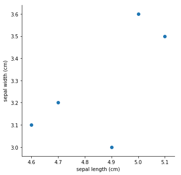

```python
import seaborn as sns
import matplotlib.pyplot as plt

sns.FacetGrid(x, height=5) \
    .map(plt.scatter, "sepal length (cm)", "sepal width (cm)") \
    .add_legend()

plt.show()
```

Di sini kita perlu bantuan Seaborn dan Matplotlib, jiga belum punya mereka maka harus install terlebih dahulu ya.

Kita menggunakan plot pola dari FacetGrid dengan metode scatter, "sepal length (cm)" sebagai nilai sumbu X yang dipanggil harus sesuai dengan nama kolom di dataframe, sedangkan "sepal width (cm)" sebagai nilai sumbu Y yang juga harus sama dengan nama kolom di dataframe. Height menyatakan ukuran chartnya.

# Tugas #5

Soal:

- Mencari statistika dasar dari iris dataframe;

**Jawaban dari soal 5:**

```python
iris_df.describe()
```

|  | sepal length (cm) | sepal width (cm) | petal length (cm) | petal width (cm) |
| --- | --- | --- | --- | --- |
| count | 150.000000 | 150.000000 | 150.000000 | 150.000000 |
| mean | 5.843333 | 3.057333 | 3.758000 | 1.199333 |
| std | 0.828066 | 0.435866 | 1.765298 | 0.762238 |
| min | 4.300000 | 2.000000 | 1.000000 | 0.100000 |
| 25% | 5.100000 | 2.800000 | 1.600000 | 0.300000 |
| 50% | 5.800000 | 3.000000 | 4.350000 | 1.300000 |
| 75% | 6.400000 | 3.300000 | 5.100000 | 1.800000 |
| max | 7.900000 | 4.400000 | 6.900000 | 2.500000 |

Selamat,, kita telah menyelesaikan tugas pertama di program pelatihan ini. Semoga kita paham akan apa yang kita kerjakan :)

Sekian dan..

# ** Terima Kasih **

*Very important note:*  
Bagi teman-teman yang mengalami kendala memahami materi atau bagi yang ingin sekedar sharing ilmu pengetahuan teknis mengenai apa yang kita pelajari di kelas, mari sempatkan sesekali hadir di kegiatan diskusi luar kelas. Hubungi ketua kelas untuk informasi lebih lanjut! *We will be so happy to have you* :)